# Analysing the effects of climate change and forest disturbance on vegetation dynamics in the boreal forest

Theresa Meier, 25.04.2024

## Exploratory Analysis: FPCA

Note that no linear differential operator was constructed so far. This could be a mean to improve the fit even further. The following analysis is conducted with penalizing the forth derivative. The results for penalizing the third derivative are pretty similar, with only the starting years changing. The PC scores however are nearly the same as for penalizing the forth derivative, so the final interpretation is hardly affected.

### Basis Representation - Needleleaf Evergreen

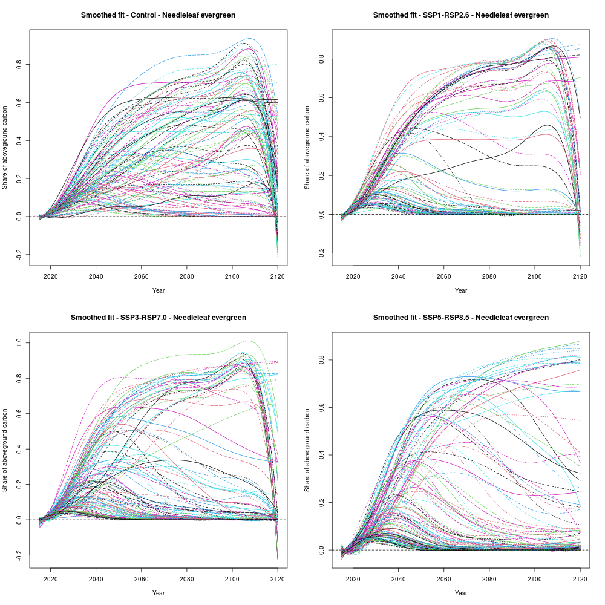

**Figure 2:** Smoothed basis representation for Needleleaf Evergreen and all four scenarios. Here, the forth derivative of the 6-order-splines is penalized.

As a second step, data registration is considered. Unfortunately, the function `landmarkreg` (package `fda`) is not available, so no landmark registration is possible without self implementation. Thus, the curves are being registered with function `register.fd` which is not based on landmarks but on aligning with the mean function. As stated by Ramsay et al. (2009), this type of registration should usually be conducted after landmark registration. Figure 3 shows the registered curves for * Needleleaf Evergreen*.

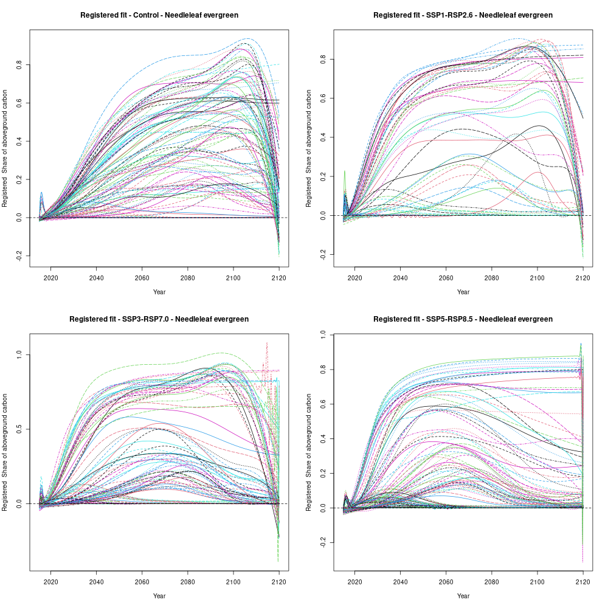

### Principal Component Analysis - Needleleaf Evergreen

To further analyze the data, a FPCA is run for each of the four scenarios and each of the five PFTs separately. Again, let’s take a look at the two principal components for each scenario of PFT *Needleleaf Evergreen*. Figure 4 shows the unregistered principal components.

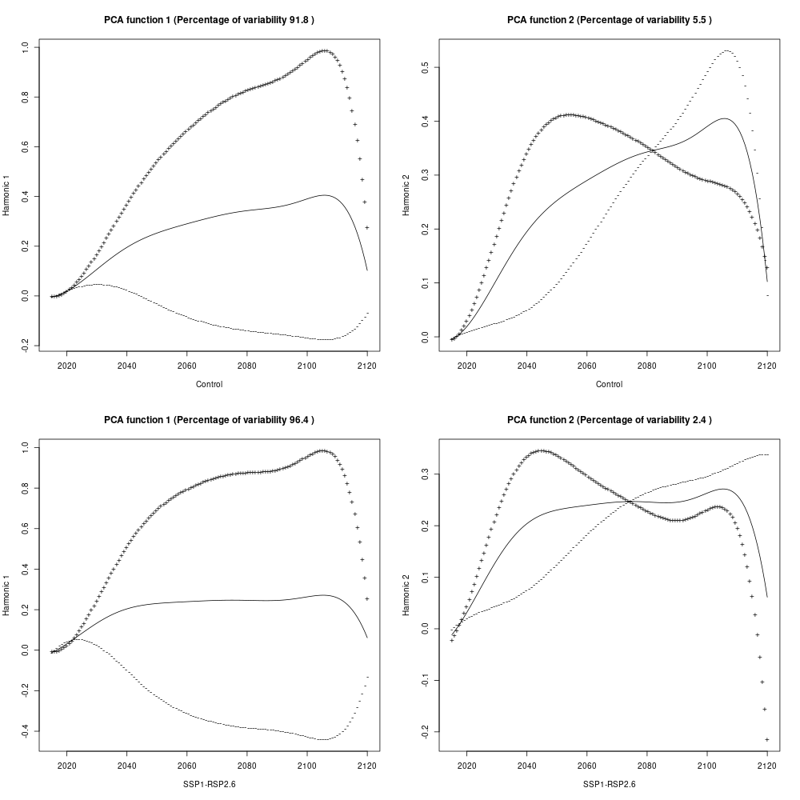

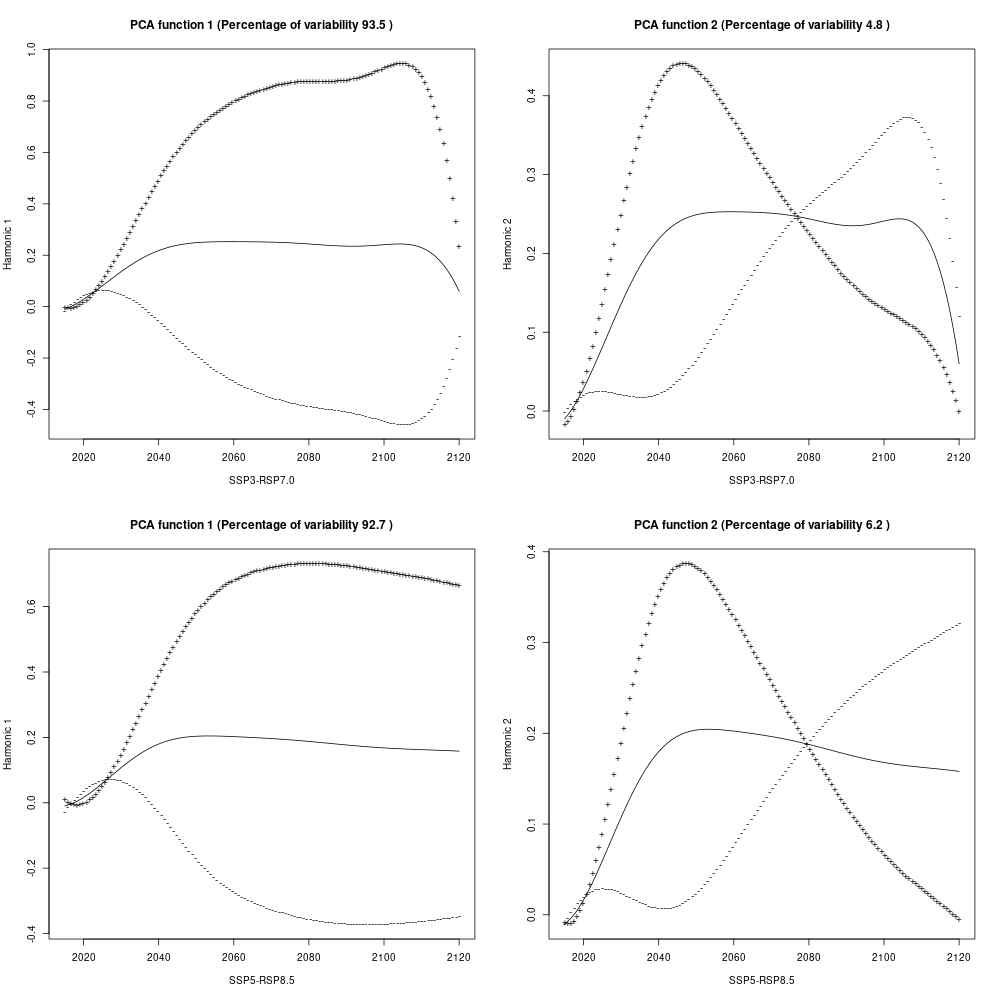

The first principal component reflects a higher or lower peak in the share of aboveground carbon.

#### With registration

Figure 5 shows the two principal components for each scenario for the registered curves.

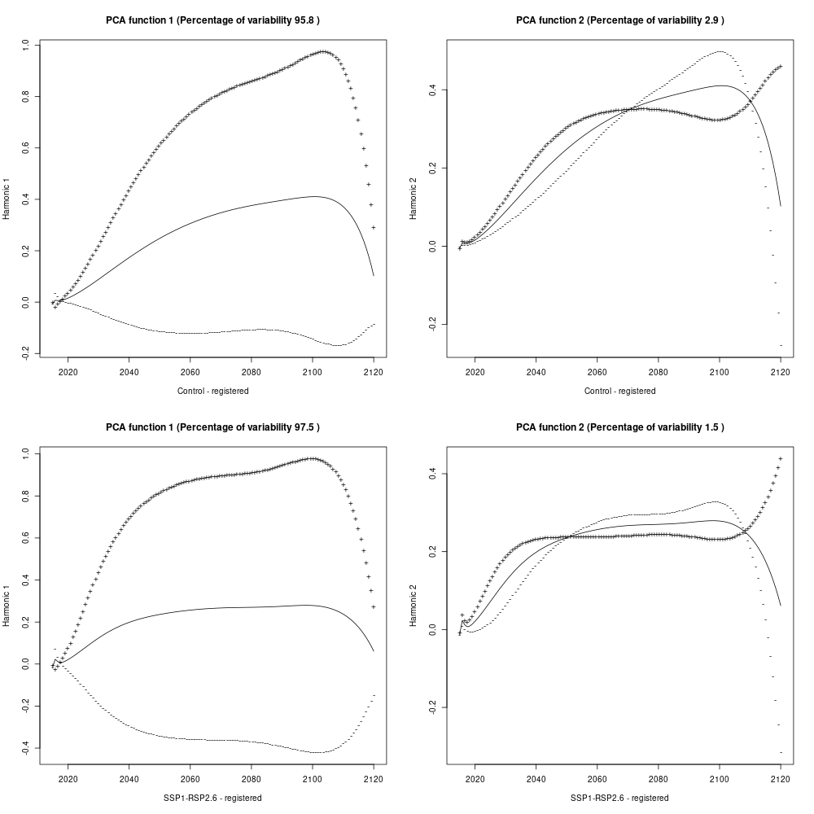

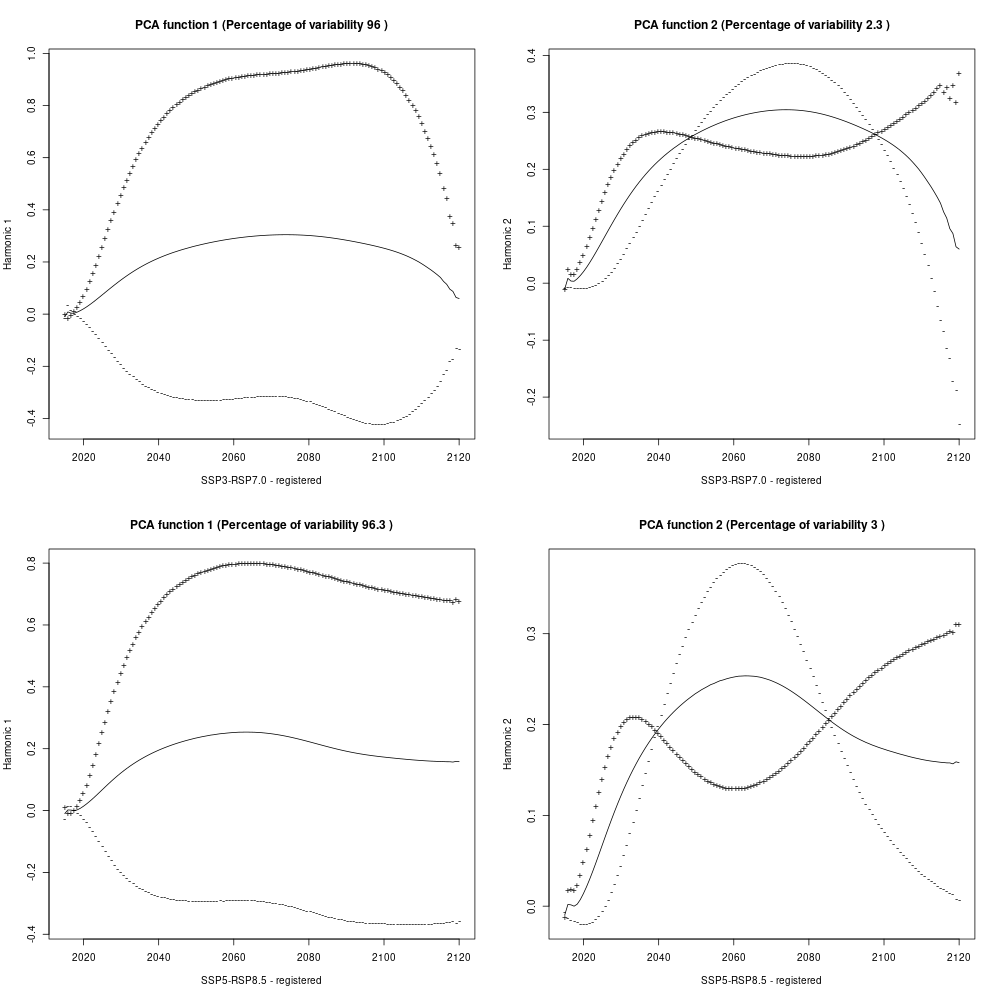

We can see that the effects are less pronounced than in the unregistered case, which is not surprising since the registration process removes some of the variability in the data.

#### With VARIMAX rotation

For a better understanding and an easier interpretation of the principal components, a VARIMAX rotation is applied.

Figure 6 shows the VARIMAX rotated first and second principal components for each scenario.

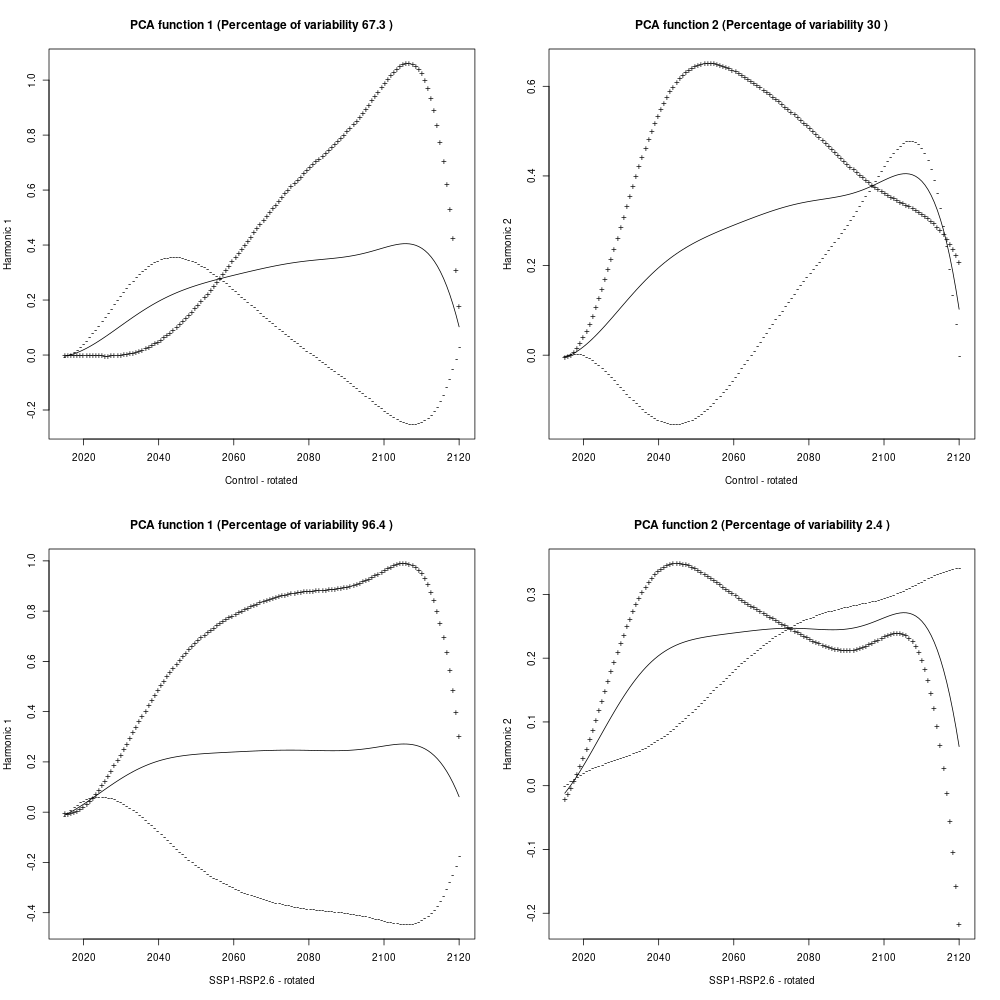

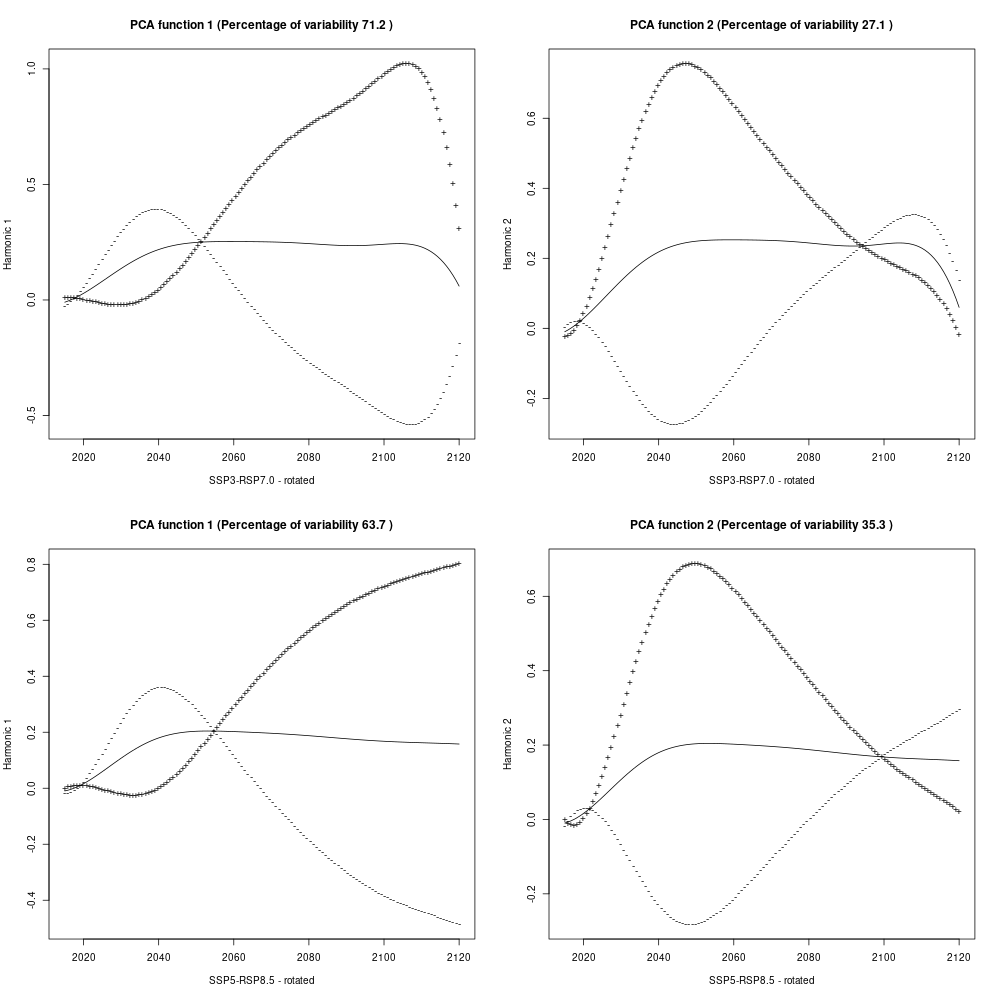

### Cluster detection: PC1 vs. PC2 - Needleleaf Evergreen

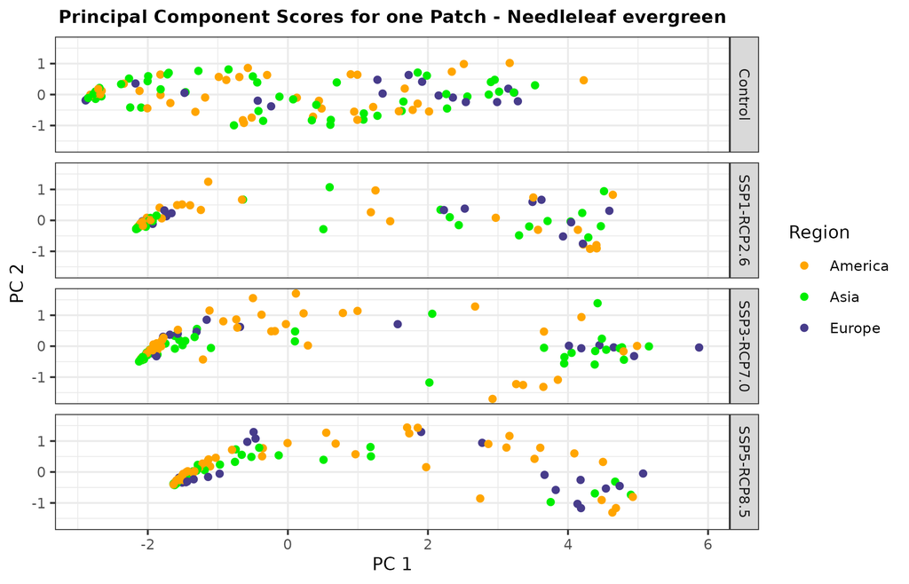

**Figure 7:** First principal component vs. second principal component for each scenario for PFT *Needleleaf Evergreen*.

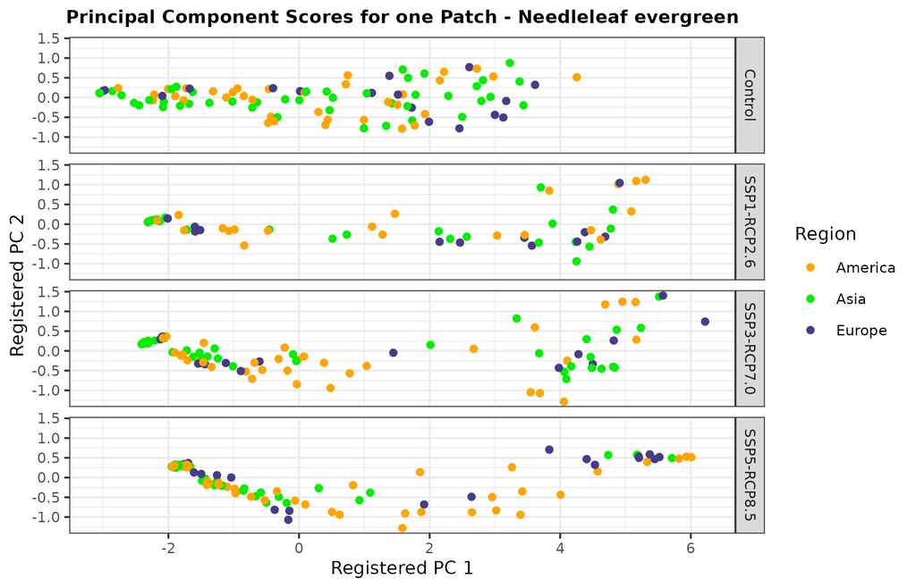

**Figure 8:** First registered principal component vs. second registered principal component for each scenario for PFT *Needleleaf Evergreen*.

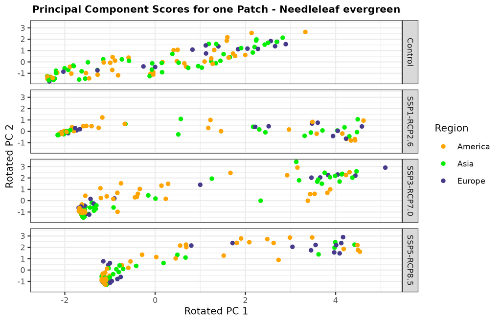

**Figure 9:** First VARIMAX rotated component vs. second VARIMAX rotated component for each scenario for PFT *Needleleaf Evergreen*